# 05_Ordination.Rmd

Morrow Zhang

2026-04-27

# Goal

Load in phyloseq data with rooted tree and colors and functions. Evaluate sequencing depth and remove samples, if needed. Normalize the read counts between samples. Calculate community dissimilarities. Numbers between 0 and 1. If 0, completely similar versus if they are 1, then they’re completely dissimilar. Sorensen: Shared Species as a binary value: Abundance-unweighted Bray-Curtis: Shared Abundant species: Abundance-weighted (Abundance-)Weighted UNIFRAC: Consider Abundant Species and where they fall on the tree Visualize the community data with two unconstrained Ordinations: PCoA: Linear Method. Eigenvalue = how much variation is explained by each axis. Choose to view axis 1, 2, 3, etc. and plot them together. NMDS: Non-linear. Smush multiple Dimensions into 2 or 3 axes. Need to report Stress value (ideally <0.15). Run statistics with functions from the vegan R package: PERMANOVA with adonis2(). betadispR with betadisper() and permutest().

# Scientific Question

### Interpretation 1

Scientific Question: Do hospitalized patients with MDD who have made a recent suicide attempt have distinct microbial community composition compared to MDD patients without a history of suicide attempts?

Null Hypothesis: Gut microbial community composition does not differ between hospitalized MDD patients with a recent suicide attempt and those without a history of suicide attempts.

Alternative Hypothesis: Hospitalized MDD patients with a recent suicide attempt have significantly different microbial community composition compared to MDD patients without a history of suicide attempts.

These hypotheses relate to both abundance-unweighted and abundance-weighted-beta diversity metrics. Abundance-unweighted metrics test whether different microbial taxa are present between attempters and non-attempters, while abundance-weighted metrics test whether dominant taxa differ in relative abundance between groups.

# load in data

```r
# load phyloseq object
load("data/preprocessed_phyloseq.RData")
preprocessed_physeq
```

```
## phyloseq-class experiment-level object
## otu_table()   OTU Table:         [ 2886 taxa and 49 samples ]
## sample_data() Sample Data:       [ 49 samples by 37 sample variables ]
## tax_table()   Taxonomy Table:    [ 2886 taxa by 9 taxonomic ranks ]
```

```r
min(sample_sums(preprocessed_physeq))
```

```
## [1] 12368
```

# Remove outlier if any

```r
# There is no outlier to remove

sort(sample_sums(preprocessed_physeq))
```

```
## SRR35320081 SRR35320118 SRR35320075 SRR35320078 SRR35320124 SRR35320122
##       12368       15107       17176       17534       20917       21234
## SRR35320123 SRR35320086 SRR35320121 SRR35320094 SRR35320088 SRR35320110
##       21842       22153       22401       22419       23355       23764
## SRR35320093 SRR35320080 SRR35320077 SRR35320113 SRR35320082 SRR35320091
##       24112       24160       24450       24759       25002       25958
## SRR35320120 SRR35320076 SRR35320117 SRR35320141 SRR35320115 SRR35320116
##       26301       26366       26392       26452       26635       26653
## SRR35320090 SRR35320079 SRR35320073 SRR35320072 SRR35320074 SRR35320111
##       26815       26857       26875       27531       27623       27706
## SRR35320087 SRR35320119 SRR35320089 SRR35320112 SRR35320085 SRR35320084
##       27896       28375       28561       28816       29211       30061
## SRR35320095 SRR35320128 SRR35320071 SRR35320140 SRR35320041 SRR35320114
##       33564       35400       37841       38175       38755       38819
## SRR35320139 SRR35320092 SRR35320126 SRR35320062 SRR35320051 SRR35320100
##       40271       42749       42990       45397       45635       46539
## SRR35320125
##       46910
```

```r
# create metadata frame
metadata_df <-
  preprocessed_physeq %>%
  sample_data() %>%
  data.frame()
```

# Normalize the Read Depth

## Explore the raw read counts

```r
raw_TotalSeqs_df <-
  preprocessed_physeq %>%
  # Calculate the total number of sequences/reads
  sample_sums() %>%
  data.frame()

# Take a look
head(raw_TotalSeqs_df)
```

```
##                 .
## SRR35320041 38755
## SRR35320051 45635
## SRR35320062 45397
## SRR35320071 37841
## SRR35320072 27531
## SRR35320073 26875
```

```r
colnames(raw_TotalSeqs_df)[1] <- "TotalSeqs"

# add a new column of num_ASVs (RAW, non-noramlized # ASVs)
raw_TotalSeqsASVs_df <-
  raw_TotalSeqs_df %>%
  mutate(num_ASVs = colSums(otu_table(preprocessed_physeq) > 1))

# View(raw_TotalSeqsASVs_df)

#  histogram of seq depth
rawSeq_histogram <-
  raw_TotalSeqsASVs_df %>%
  ggplot(aes(x = TotalSeqs)) +
  geom_histogram(bins = 50) +
  labs(title = "Raw Seq Depth Histogram") +
  theme_bw()

# Seq Depth versus num_ASVs
rawSeq_vs_numASV_plot <-
  raw_TotalSeqsASVs_df %>%
  ggplot(aes(x = num_ASVs, y = TotalSeqs)) +
  geom_point() +
  geom_smooth(method = "lm") +
  labs(title = "Raw Seq Depth vs # ASVs") +
  theme_bw()

# test significance?
summary(lm(TotalSeqs ~ num_ASVs, data = raw_TotalSeqsASVs_df))
```

```
##
## Call:
## lm(formula = TotalSeqs ~ num_ASVs, data = raw_TotalSeqsASVs_df)
##
## Residuals:
##    Min     1Q Median     3Q    Max
## -10028  -5175  -1197   1362  18325
##
## Coefficients:
##             Estimate Std. Error t value Pr(>|t|)
## (Intercept) 17126.82    3535.92   4.844 1.42e-05 ***
## num_ASVs       70.04      20.00   3.501  0.00103 **
## ---
## Signif. codes:  0 '***' 0.001 '**' 0.01 '*' 0.05 '.' 0.1 ' ' 1
##
## Residual standard error: 7557 on 47 degrees of freedom
## Multiple R-squared:  0.2069, Adjusted R-squared:   0.19
## F-statistic: 12.26 on 1 and 47 DF,  p-value: 0.001026
```

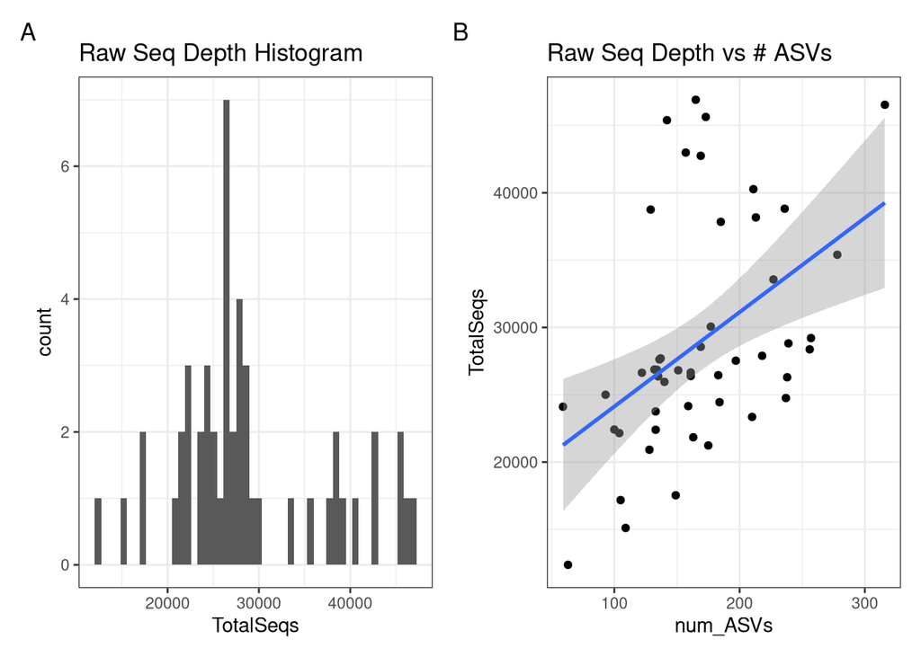

```r
# put plots together

rawSeq_histogram + rawSeq_vs_numASV_plot +
  plot_annotation(tag_levels = "A")
```

```r
# save the plot
combined_rawSeq_plot <-
  rawSeq_histogram +
  rawSeq_vs_numASV_plot +
  plot_annotation(tag_levels = "A")

ggsave(
  filename = "figures/05_Ordination/rawSeq_depth_and_ASVs.png",
  plot = combined_rawSeq_plot,
  width = 10,
  height = 5,
  dpi = 300
)
```

### INTERPRETATION 2

The read counts were scaled to 12,368 reads per sample, which is the minimum sequencing depth observed in the dataset. This value was chosen to retain all samples while standardizing sequencing depth across samples.

Scaling to this minimum depth may result in the loss of rare taxa from samples with higher sequencing depth. However, it ensures that downstream beta-diversity comparisons reflect true biological differences rather than differences caused by uneven sequencing depth.

# Scale the Read Counts

```r
min(sample_sums(preprocessed_physeq))
```

```
## [1] 12368
```

```r
# Scale the reads

scaled_physeq <-
  preprocessed_physeq %>%
  scale_reads(round = "matround")

# Look at it
scaled_physeq
```

```
## phyloseq-class experiment-level object
## otu_table()   OTU Table:         [ 2879 taxa and 49 samples ]
## sample_data() Sample Data:       [ 49 samples by 37 sample variables ]
## tax_table()   Taxonomy Table:    [ 2879 taxa by 9 taxonomic ranks ]
```

```r
# Look at it more!
#View(data.frame(otu_table(preprocessed_physeq)))
#View(data.frame(otu_table(scaled_physeq)))

# Confirm seq read depth of scaled_physeq
scaled_TotalSeqs_df <-
  scaled_physeq %>%
  sample_sums() %>%
  data.frame()

colnames(scaled_TotalSeqs_df)[1] <- "TotalSeqs"

# add a new column of num_ASVs (RAW, non-noramlized # ASVs)
scaled_TotalSeqsASVs_df <-
  scaled_TotalSeqs_df %>%
  mutate(num_ASVs = colSums(otu_table(scaled_physeq) > 1))

# Plot it!
scaledSeq_histogram <-
  scaled_TotalSeqs_df %>%
  ggplot(aes(x = TotalSeqs)) +
  geom_histogram(bins = 50) +
  labs(title = "Scaled Seq Depth Histogram") +
  #scale_x_continuous(limits = c(0, 7500)) +
  theme_bw()

# Scaling always gives us a range!
# MInimum sequences
min(scaled_TotalSeqs_df$TotalSeqs)
```

```
## [1] 12322
```

```r
# Total Range
range(scaled_TotalSeqs_df)
```

```
## [1] 12322 12384
```

```r
# How many is that range?
range_seqs <- (max(scaled_TotalSeqs_df$TotalSeqs) - min(scaled_TotalSeqs_df$TotalSeqs))
range_seqs
```

```
## [1] 62
```

```r
# And in terms of percent?
range_seqs/max(scaled_TotalSeqs_df$TotalSeqs)
```

```
## [1] 0.00500646
```

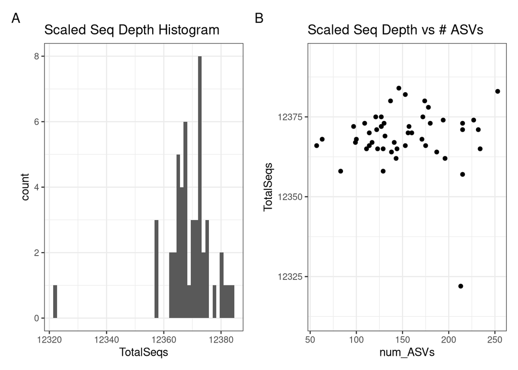

```r
#View(scaled_TotalSeqs_df)

# Set the axis min and max for the next plot
max_y <- max(scaled_TotalSeqs_df$TotalSeqs) + 10
min_y <- min(scaled_TotalSeqs_df$TotalSeqs) - 10

# Now, draw the plot
scaledSeq_vs_numASV_plot <-
  scaled_TotalSeqsASVs_df %>%
  ggplot(aes(x = num_ASVs, y = TotalSeqs)) +
  geom_point() +
  scale_y_continuous(limits = c(min_y, max_y)) +
  #geom_smooth(method = "lm") +
  theme_bw() +
  labs(title = "Scaled Seq Depth vs # ASVs")

# Put the two plots together.
scaledSeq_histogram + scaledSeq_vs_numASV_plot +
  plot_annotation(tag_levels = "A")
```

```r
combined_scaledSeq_plot <-
  scaledSeq_histogram +
  scaledSeq_vs_numASV_plot +
  plot_annotation(tag_levels = "A")

# Save figure
ggsave(
  filename = "figures/05_Ordination/scaledSeq_depth_and_ASVs.png",
  plot = combined_scaledSeq_plot,
  width = 10,
  height = 5,
  dpi = 300
)
```

### INTERPRETATION 3

Yes, the total number of sequences across samples is in the same general range after scaling. The sequencing depth ranges from 12,322 to 12,384 reads, with a total range of 62 reads.

This indicates that sequencing depth has been effectively standardized across samples. As a result, differences in the observed number of ASVs are less likely to be driven by sequencing depth and more likely to reflect true biological differences among samples.

# Calculating dissimarity

```r
# Sorensen Dissimiliarty
scaled_sorensen_dist <- phyloseq::distance(scaled_physeq, method = "bray", binary = TRUE)

# What does it look like?
class(scaled_sorensen_dist)
```

```
## [1] "dist"
```

```r
str(scaled_sorensen_dist)
```

```
##  'dist' num [1:1176] 0.722 0.749 0.764 0.785 0.762 ...
##  - attr(*, "maxdist")= num 1
##  - attr(*, "Size")= int 49
##  - attr(*, "Labels")= chr [1:49] "SRR35320041" "SRR35320051" "SRR35320062" "SRR35320071" ...
##  - attr(*, "Diag")= logi FALSE
##  - attr(*, "Upper")= logi FALSE
##  - attr(*, "method")= chr "binary bray"
##  - attr(*, "call")= language vegdist(x = c(762, 1348, 3352, 1704, 1968, 1271, 1672, 4163, 964, 283,  2108, 2391, 3180, 1921, 1079, 2303, 3140,| __truncated__ ...
```

```r
#head(as.matrix(scaled_sorensen_dist))

# Bray-Curtis Dissimiliarty
scaled_bray_dist <- phyloseq::distance(scaled_physeq, method = "bray", binary = FALSE)

# Abundance-Unweighted UniFrac
#scaled_uUnifrac_dist <- phyloseq::distance(scaled_physeq, method = "unifrac")

# Abundance-Weighted UniFrac
#scaled_wUnifrac_dist <- phyloseq::distance(scaled_physeq, method = "wunifrac")
```

### INTERPRETATION 4

Bray-Curtis is the dissimilarity metric most related to my scientific question because it accounts for differences in taxa abundance between groups, which is important for comparing microbial community composition between attempters and non-attempters.

# Visualize Community Dissimilarity with Ordination

```r
# First, calculate PCoA with Soresen
scaled_soren_pcoa <-
  ordinate(physeq = scaled_physeq,
         method = "PCoA",
         distance = "bray", binary = TRUE)

# Take a quick look
str(scaled_soren_pcoa)
```

```
## List of 5
##  $ correction: chr [1:2] "none" "1"
##  $ note      : chr "There were no negative eigenvalues. No correction was applied"
##  $ values    :'data.frame':  48 obs. of  5 variables:
##   ..$ Eigenvalues   : num [1:48] 1.741 0.951 0.688 0.598 0.537 ...
##   ..$ Relative_eig  : num [1:48] 0.1203 0.0657 0.0475 0.0413 0.0371 ...
##   ..$ Broken_stick  : num [1:48] 0.0929 0.0721 0.0616 0.0547 0.0495 ...
##   ..$ Cumul_eig     : num [1:48] 0.12 0.186 0.234 0.275 0.312 ...
##   ..$ Cumul_br_stick: num [1:48] 0.0929 0.1649 0.2266 0.2813 0.3308 ...
##  $ vectors   : num [1:49, 1:48] -0.096 -0.2223 -0.2818 -0.1284 -0.0243 ...
##   ..- attr(*, "dimnames")=List of 2
##   .. ..$ : chr [1:49] "SRR35320041" "SRR35320051" "SRR35320062" "SRR35320071" ...
##   .. ..$ : chr [1:48] "Axis.1" "Axis.2" "Axis.3" "Axis.4" ...
##  $ trace     : num 14.5
##  - attr(*, "class")= chr "pcoa"
```

```r
sample_data(preprocessed_physeq)$AttemptStatus <-
  ifelse(
    grepl("non attempter|non attempters", sample_data(preprocessed_physeq)$source_material_id, ignore.case = TRUE),
    "Non-attempter",
    ifelse(
      grepl("attempter|attempters", sample_data(preprocessed_physeq)$source_material_id, ignore.case = TRUE),
      "Attempter",
      NA
    )
  )
```

```r
# add in necessary metadata
sample_df <- data.frame(sample_data(scaled_physeq))

sample_df$AttemptStatus <- ifelse(
  grepl("non", sample_df$source_material_id, ignore.case = TRUE),
  "Non-attempter",
  ifelse(
    grepl("attempt", sample_df$source_material_id, ignore.case = TRUE),
    "Attempter",
    NA
  )
)

sample_data(scaled_physeq) <- sample_data(sample_df)

table(sample_data(scaled_physeq)$AttemptStatus, useNA = "ifany")
```

```
##
##     Attempter Non-attempter
##            35            14
```

# PCoA

```r
# attempt_colors <- c(
#  "Attempter" = "red",
#  "Non-attempter" = "blue"
#)

#soren_pcoa_plot <-
  # plot_ordination(
    # physeq = preprocessed_physeq,
    # ordination = soren_pcoa,
    # color = "AttemptStatus",
    # title = "Sorensen PCoA"
  # ) +
  # geom_point(size = 5, alpha = 0.7) +
  # scale_color_manual(values = attempt_colors) +
  # theme_bw() +
  # theme(legend.position = "right")

# Bray-Curtis

# bray_pcoa_plot <-
  # plot_ordination(
    # physeq = preprocessed_physeq,
    # ordination = bray_pcoa,
    # color = "AttemptStatus",
    # title = "Bray-Curtis PCoA"
  # ) +
  # geom_point(size = 5, alpha = 0.7) +
  # scale_color_manual(values = attempt_colors) +
  # theme_bw() +
  # theme(legend.position = "right")

# soren_pcoa_plot + bray_pcoa_plot +
  # plot_layout(guides = "collect") +
  # plot_annotation(tag_levels = "A")

# combined_pcoa_plot <-
  # soren_pcoa_plot +
  # bray_pcoa_plot +
  # plot_layout(guides = "collect") +
  # plot_annotation(tag_levels = "A")


# ggsave(
  # filename = "figures/05_Ordination/sorensen_bray_pcoa.png",
  # plot = combined_pcoa_plot,
  # width = 10,
  # height = 5,
  # dpi = 300
# )
```

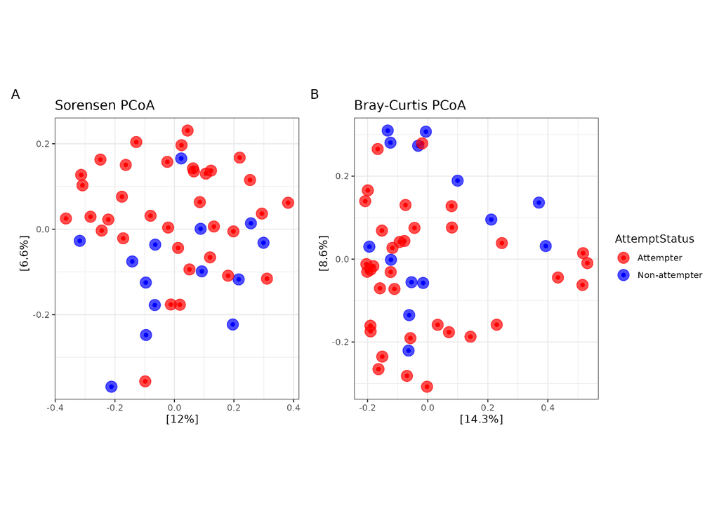

```r
 # I have this extra chunk, because when I try to knit the previous chunk, it always gives me error when it could run normally in R (not when I was trying to knit)
# I decided to comment out the previous chunk and just load my generated image below from my saved figures.


library(png)
library(grid)

img <- png::readPNG("figures/05_Ordination/sorensen_bray_pcoa.png")

grid.newpage()
grid.raster(img)
```

### INTERPRETATION 5

The PCoA plots generated using Sorensen and Bray-Curtis dissimilarity show substantial overlap between attempters and non-attempters, although a few individual samples appear separated from the main clusters. This indicates that while some samples differ in microbial composition, there is no strong overall clustering of samples by AttemptStatus. The lack of clear group separation in both plots suggests that microbial community composition is not strongly differentiated between attempters and non-attempters based on visual inspection alone.

# NMDS: Non-Metric Multidimensional Scaling

```r
## SORENSEN


attempt_colors <- c(
  "Attempter" = "red",
  "Non-attempter" = "blue"
)

scaled_soren_nmds <-
  ordinate(
    physeq = scaled_physeq,
    method = "NMDS",
    distance = "bray",
    binary = FALSE
  )
```

```
## Square root transformation
## Wisconsin double standardization
## *** Best solution was not repeated -- monoMDS stopping criteria:
##     20: stress ratio > sratmax
```

```r
soren_nmds_plot <-
  plot_ordination(
    physeq = scaled_physeq,
    ordination = scaled_soren_nmds,
    color = "AttemptStatus",
    title = "Sorensen NMDS"
  ) +
  scale_color_manual(values = attempt_colors) +
  geom_point(size = 5, alpha = 0.5) +
  theme_bw() +
  theme(legend.position = "right")
### Bray-Curtis
# Second, calculate NMDS with Bray-Curtis
bray_nmds <-
  ordinate(
    physeq = preprocessed_physeq,
    method = "NMDS",
    distance = "bray",
    binary = FALSE
  )
```

```
## Square root transformation
## Wisconsin double standardization
## *** Best solution was not repeated -- monoMDS stopping criteria:
##      1: no. of iterations >= maxit
##     17: stress ratio > sratmax
##      2: scale factor of the gradient < sfgrmin
```

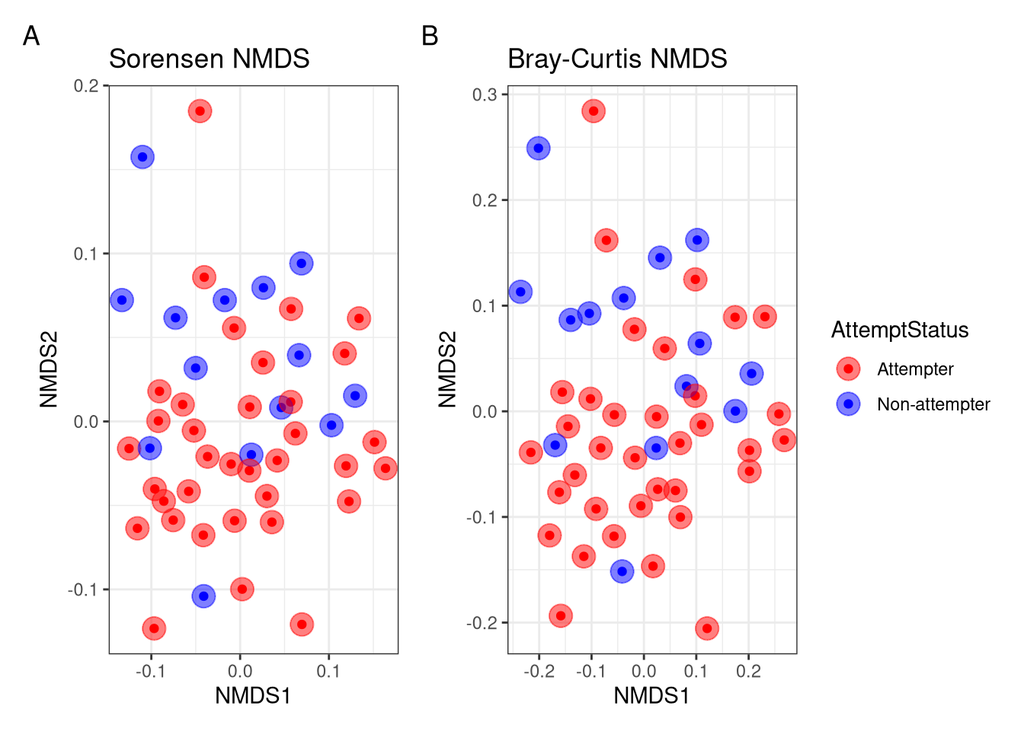

```r
# Plot it: Bray-Curtis NMDS
bray_nmds_plot <-
  plot_ordination(
    physeq = preprocessed_physeq,
    ordination = bray_nmds,
    color = "AttemptStatus",
    title = "Bray-Curtis NMDS"
  ) +
  scale_color_manual(values = attempt_colors) +
  geom_point(size = 5, alpha = 0.5) +
  theme_bw() +
  theme(legend.position = "right")

# Show the plots
soren_nmds_plot + bray_nmds_plot +
  plot_layout(guides = "collect") +
  plot_annotation(tag_levels = "A")
```

```r
combined_nmds_plot <-
  soren_nmds_plot + bray_nmds_plot +
  plot_layout(guides = "collect") +
  plot_annotation(tag_levels = "A")

ggsave(
  filename = "figures/05_Ordination/NMDS_Sorensen_BrayCurtis.png",
  plot = combined_nmds_plot,
  width = 10,
  height = 5,
  dpi = 300
)
```

### INTERPRETATION 6

# All ordinations together

[figure not shown]

```r
# I run into the same issue again, so I have commentted codes out and just load the saved figure.

#all_ordination_plot <-
#  soren_pcoa_plot + bray_pcoa_plot +
#soren_nmds_plot + bray_nmds_plot +
#  plot_layout(guides = "collect") +
#  plot_annotation(tag_levels = "A")

#all_ordination_plot

#ggsave(
#  filename = "figures/05_Ordination/All_Ordinations_PCoA_NMDS.png",
#  plot = all_ordination_plot,
#  width = 10,
 # height = 8,
 # dpi = 300
#)

img <- png::readPNG("figures/05_Ordination/All_Ordinations_PCoA_NMDS.png")

grid.newpage()
grid.raster(img)
```

### INTERPRETATION 7

Both PCoA and NMDS show substantial overlap between attempters and non-attempters, indicating no clear separation of microbial community composition between groups. Therefore, both ordination methods support the same biological conclusion that microbial communities are not strongly differentiated by AttemptStatus.

```r
## 1. Run with by = terms for R² values, sensitive to order of variables!
## ALWAYS check and confirm the order of your terms and how they interact with each other.
sorensen_attempt_adonis <- adonis2(
  scaled_sorensen_dist ~ AttemptStatus,
  data = data.frame(sample_data(scaled_physeq)),
  by = "terms"
)

sorensen_attempt_adonis
```

```
## Permutation test for adonis under reduced model
## Terms added sequentially (first to last)
## Permutation: free
## Number of permutations: 999
##
## adonis2(formula = scaled_sorensen_dist ~ AttemptStatus, data = data.frame(sample_data(scaled_physeq)), by = "terms")
##               Df SumOfSqs     R2      F Pr(>F)
## AttemptStatus  1   0.3704 0.0256 1.2349  0.098 .
## Residual      47  14.0970 0.9744
## Total         48  14.4674 1.0000
## ---
## Signif. codes:  0 '***' 0.001 '**' 0.01 '*' 0.05 '.' 0.1 ' ' 1
```

```r
# Bray-Curtis
## ALWAYS check and confirm the order of your terms and how they interact with each other.
bray_attempt_adonis_terms1 <-
  adonis2(
    scaled_bray_dist ~ AttemptStatus,
    data = data.frame(sample_data(scaled_physeq)),
    by = "terms"
  )

bray_attempt_adonis_terms1
```

```
## Permutation test for adonis under reduced model
## Terms added sequentially (first to last)
## Permutation: free
## Number of permutations: 999
##
## adonis2(formula = scaled_bray_dist ~ AttemptStatus, data = data.frame(sample_data(scaled_physeq)), by = "terms")
##               Df SumOfSqs      R2      F Pr(>F)
## AttemptStatus  1   0.3837 0.02653 1.2808  0.128
## Residual      47  14.0804 0.97347
## Total         48  14.4641 1.00000
```

### INTERPRETATION 8

Because only one variable (AttemptStatus) was included in the model, testing different term orders was not applicable. Therefore, R² values could not change due to term order, and there is no indication of interactions or co-varying predictors in this model.

These statistical results are consistent with the ordination analyses (PCoA and NMDS), where substantial overlap was observed between attempter and non-attempter samples. This overlap suggests weak separation between groups and supports the finding that community composition is similar across AttemptStatus groups.

Biologically, these results suggest that suicide attempt status is not a strong driver of microbial community composition in this dataset. Therefore, I fail to reject the null hypothesis, indicating that microbial community composition does not differ significantly between attempters and non-attempters.

# Betadisper: Testing Variances/Dispersions

## Sorensen

```r
# Homogeneity of Dispersion test with beta disper
# Sorensen Betadisper - AttemptStatus (Categorical)

dispr_sorensen_attempt <-
  betadisper(
    scaled_sorensen_dist,
    sample_data(scaled_physeq)$AttemptStatus
  )

# Permutation test
permutest(dispr_sorensen_attempt)
```

```
##
## Permutation test for homogeneity of multivariate dispersions
## Permutation: free
## Number of permutations: 999
##
## Response: Distances
##           Df   Sum Sq   Mean Sq      F N.Perm Pr(>F)
## Groups     1 0.001565 0.0015647 0.6156    999  0.443
## Residuals 47 0.119473 0.0025420
```

## Betadisper: Testing Variances/Dispersions

```r
# Bray-Curtis Betadisper - AttemptStatus (Categorical)

dispr_bray_attempt <-
  betadisper(
    scaled_bray_dist,
    sample_data(scaled_physeq)$AttemptStatus
  )

permutest(dispr_bray_attempt)
```

```
##
## Permutation test for homogeneity of multivariate dispersions
## Permutation: free
## Number of permutations: 999
##
## Response: Distances
##           Df  Sum Sq   Mean Sq      F N.Perm Pr(>F)
## Groups     1 0.00039 0.0003922 0.0538    999  0.822
## Residuals 47 0.34256 0.0072885
```

### INTERPRETATION 9

Biologically, this suggests that microbial communities within each AttemptStatus group show similar levels of variability, indicating stable within-group community structure across samples.

### INTERPRETATION 10

Biologically, these combined results suggest that suicide attempt status is not a strong driver of microbial community composition or variability in this dataset. Therefore, I fail to reject the null hypothesis and conclude that microbial communities do not differ significantly between attempters and non-attempters.

```r
end_time <- Sys.time()
end_time
```

```
## [1] "2026-04-27 11:27:17 EDT"
```

```r
elapsed_time <- round((end_time - start_time), 3)
elapsed_time
```

```
## Time difference of 17.535 secs
```